# Caseys et al. Eudicot-Botrytis interaction dataset

This notebook aims to compile and annotate the R scripts used for the analysis of the Eudicot-Botrytis dataset.

Experimental design:

Eight Eudicot species were included in this dataset including 7 crops and Arabidopsis thaliana as control. For the crops, six low improvement genotypes (wild, landraces) and six high improvement genotypes (cultivar, inbred lines) were tested. For each species, each genotype was inoculated with the collection of Botrytis isolates and replicated six time over two experiments. Detached leaves were inoculated with Botrytis in ‘experimental trays’, that constitutes a micro-environment for a randomized collection of isolates. After 72h, pictures of all trays were taken. Image analysis for calculation of lesion area (and many other parameters) was conducted in R.

0. Image analysis: For image analysis R codes, see the Image_analysis_pipeline_Final R notebook.
1. Create and restructure the dataset.

```r
source('~/Desktop/Github_Eudicot/1.Creating_Dataset.R')
```

2. Summarize the data

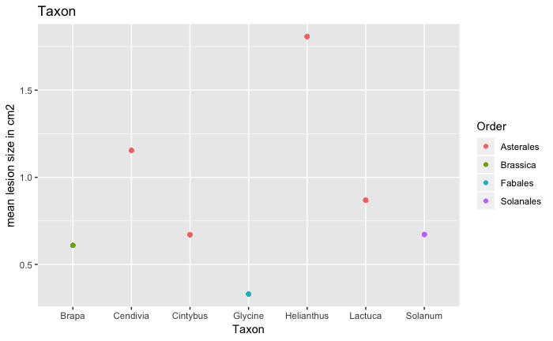

```r
source('~/Desktop/Github_Eudicot/2.Summary_RawData.R')
 ggplot(data=Summary_species, aes(Taxon, mean.sp, color=Order)) +
   geom_point()+
   ggtitle("Taxon")+
   ylab("mean lesion size in cm2")
```

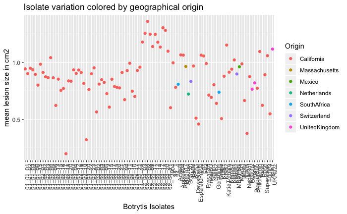

```r
  ggplot(data=Summary_Isolate, aes(IsolateID, mean.iso, color=Origin)) +
   geom_point()+
   ylab("mean lesion size in cm2")+
   ggtitle("Isolate variation colored by geographical origin")+
   xlab("Botrytis Isolates")+
   theme(axis.text.x = element_text(angle = 90, hjust = 1))
```

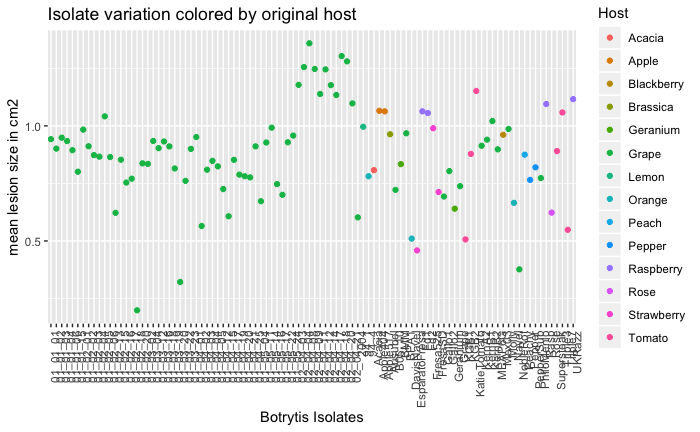

```r
ggplot(data=Summary_Isolate, aes(IsolateID, mean.iso, color=Host)) +
   geom_point()+
   ylab("mean lesion size in cm2")+
   ggtitle("Isolate variation colored by original host")+
   xlab("Botrytis Isolates")+
   theme(axis.text.x = element_text(angle = 90, hjust = 1))
```

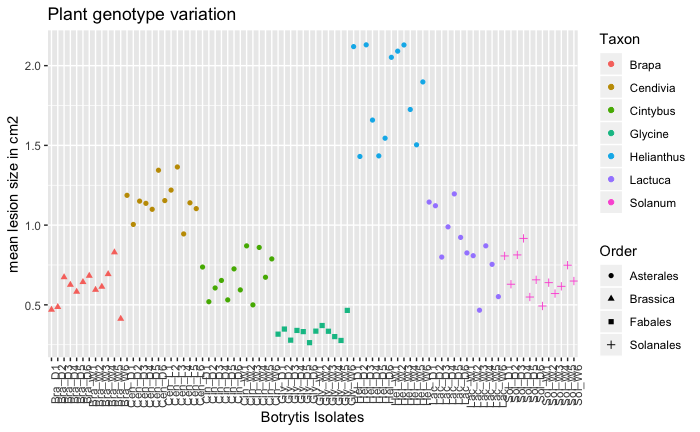

```r
ggplot(data=Summary_PGeno, aes(SNames, mean.geno, color=Taxon, shape=Order)) +
   geom_point()+
   ggtitle("Plant genotype variation")+
   ylab("mean lesion size in cm2")+
   xlab("Botrytis Isolates")+
   theme(axis.text.x = element_text(angle = 90, hjust = 1))
```

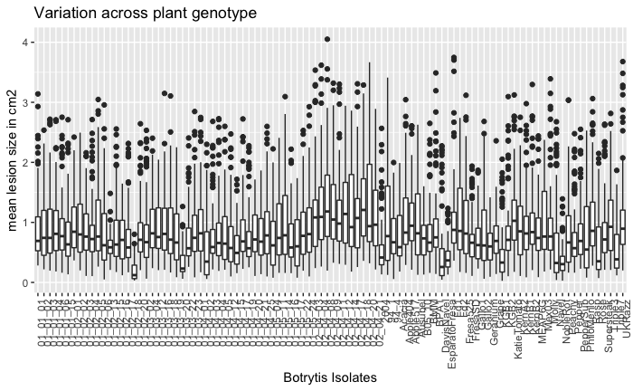

```r
ggplot(data=Summary_IsoGen , aes(Isolate, mean.isogen)) +
   geom_boxplot()+
   ggtitle("Variation across plant genotype")+
   ylab("mean lesion size in cm2")+
   xlab("Botrytis Isolates")+
   theme(axis.text.x = element_text(angle = 90, hjust = 1))
```

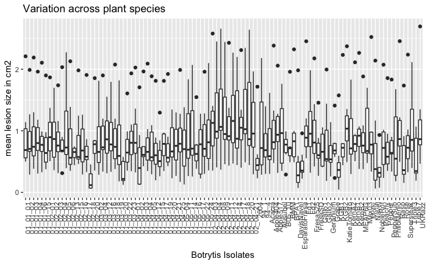

```r
ggplot(data=Summary_IsoTax , aes(Isolate, mean.isotax)) +
   geom_boxplot()+
   ggtitle("Variation across plant species")+
   ylab("mean lesion size in cm2")+
   xlab("Botrytis Isolates")+
   theme(axis.text.x = element_text(angle = 90, hjust = 1))
```

3. Data quality control This step remove the small size lesions that have high chance of being technical failure (for example the inoculation drops that did not contain Botrytis spores resulting in only the grape juice drop being phenotyped as lesion).

The pie chart provide further details to the supplementary table 5 about the lesion filtering and the percentage of lesion crossing the size and median thresholds.

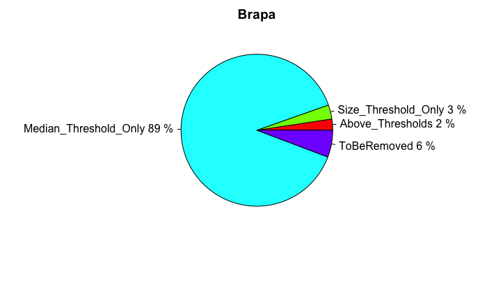

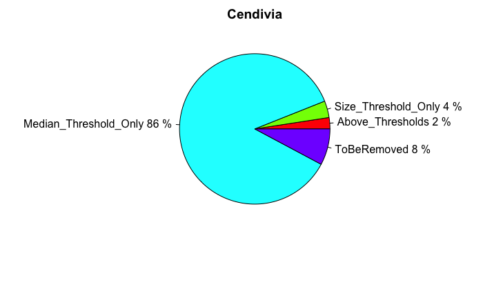

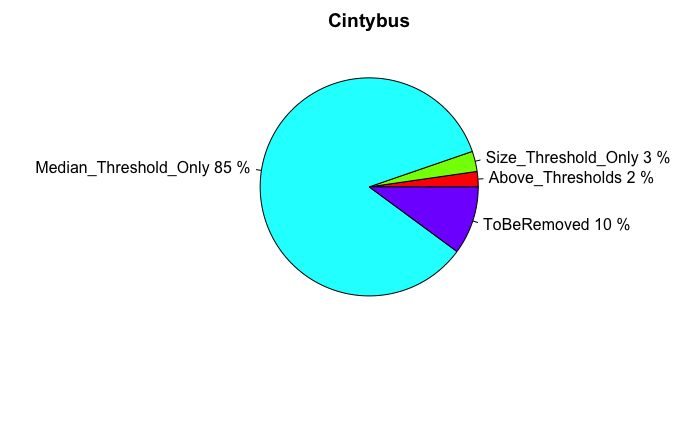

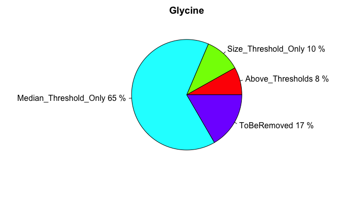

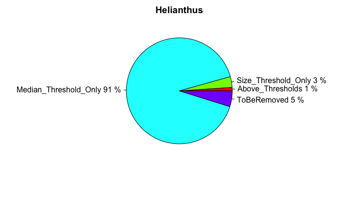

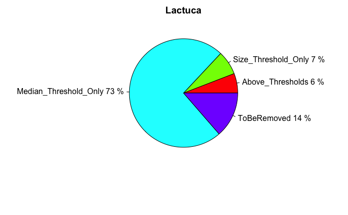

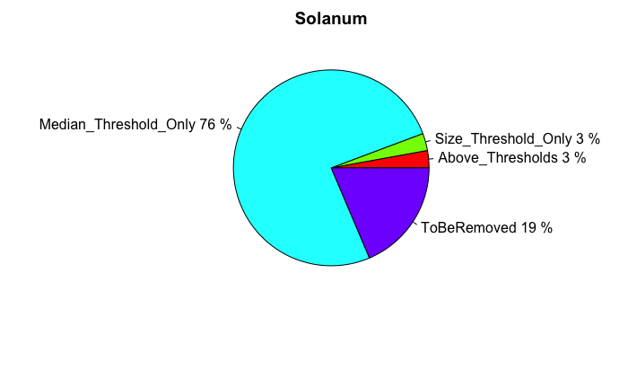

```r
source('~/Desktop/Github_Eudicot/3.Filtering_SmallLesionSize.R')
for (i in c(1:7)) {
  tmp_selection <- as.data.frame(summary(splt_Data_cleaning[[i]][,46]))
  rownames(tmp_selection) <- c("Above_Thresholds", "Size_Threshold_Only", "Median_Threshold_Only", "ToBeRemoved")
  tmpPerC <- round(tmp_selection[,1]/sum(tmp_selection[,1])*100)
  tmp_names <- paste(rownames(tmp_selection),tmpPerC, "%", sep=" ")
  pie(tmp_selection[,1], labels=tmp_names, main=Names[i], col=rainbow(length(tmp_names)))
}
```

```r
# source('~/Desktop/Github_Eudicot/4.Modeling_clean_Data.R')
# This file contains all the mixed models for each 7 crop species.
# It also calculates the least-square means.
# ! This code takes hours/days to run. !

# Let's look at the results:

ModelRes <- read.table(file="Lmer_CleanM_7sp_Perc2.txt", header = T)

ModelRes$Order <- ModelRes$Variable
levels(ModelRes$Order) <- c(8,7, 5,6, 1,4, 2, 3 )
ModelRes$Order <- as.numeric(ModelRes$Order)

ModelRes$Variable1 <-  factor(ModelRes$Variable1, levels=ModelRes$Variable1[order(ModelRes$Order)])

color_plot <- c("#762a83", "#e7d4e8", "#c2a5cf", "#762a83", "#5aae61", "#a6dba0", "#fdb863", "#c51b7d")

ggplot(ModelRes, aes(Species, Peercent, fill=Variable)) +
  geom_col()+
  scale_fill_manual(values=c("#542788", "#d8daeb", "#e08214","#1b7837","#b8e186", "#878787","#bababa","#e0e0e0" ))+
  geom_text(aes(label=Peercent), position=position_stack(vjust=0.5), size=3)+
  theme_minimal()
```

[output not shown]